# Annual Report Data Analysis - Question 3.13

Tristan Burgess and Cristin Young

2026-03-18

# 3. Did EBP/CDEP services impact clinical and functional outcomes for clients who participated?

## 3.13 To what extent did children/youth report reductions in overall distress after receiving the intervention?

**Definition:** This KPI represents the percent of assessments that show clients who have improvement from pre-post time points out of the total number of assessments from clients who discharge from the intervention and complete pre-post measures by period(s).

The YOQ total score reflects total distress in a client’s life, with a high score reflecting increased distress related to experiencing a high number of symptoms, interpersonal difficulties, and decreased satisfaction and quality of life.

**Range:** 0 - 120

**Calculation:** Sum of 30 items (0-4 scale); invalid if 3+ items missing; total score only calculated if 28+ items completed; including those doing reliably better / total who took YOQ by quarter RCI = baseline score - follow-up score - RCI ≤ -10 doing reliably worse - RCI ≥ 10 doing reliably better

**Assumptions:** A positive outcome was if a client was doing reliably better as defined by the YOQ RCI. I used follow-up quarter as the date. I used the LAST follow-up date if there were >1 assessments. I filtered out NA’s from “reliably better”; Filtered out dates before 2024-01-01 and after the date the code was run.

**Final analysis:** Regression - outcome = binary (positive or clincal cutoff met). Predictors as for 3.01

### Caregiver

```
 reliably_better   n percent
           FALSE 111     55%
            TRUE  92     45%
```

Of those with meaningful change, the following did reliably better:

```
 reliably_better  n percent
           FALSE 27     24%
            TRUE 86     76%
```

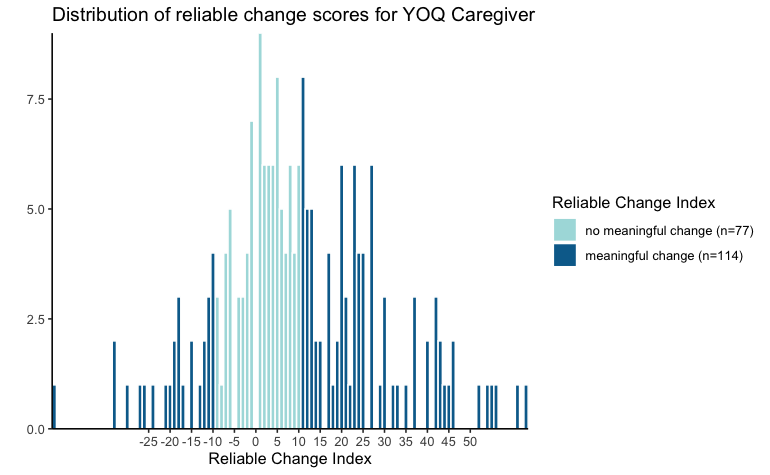

### Self

```
 reliably_better   n percent
           FALSE 274     58%
            TRUE 197     42%
```

Of those with meaningful change, the following did reliably better:

[output not shown]

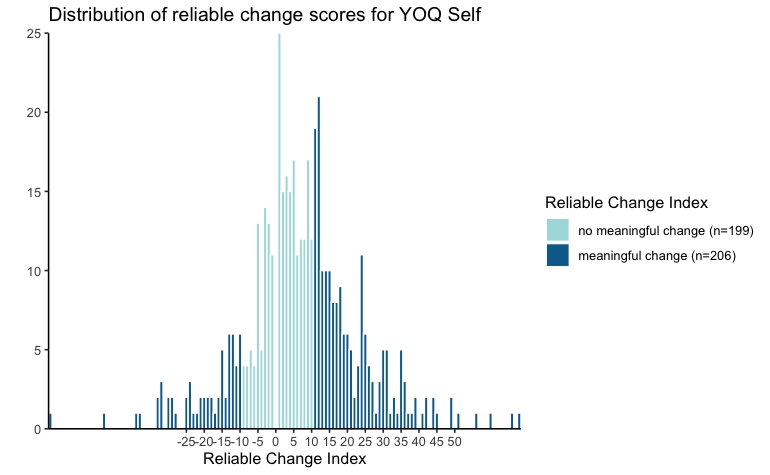